# Week 6 with Functions!

Group 3: Mara Alexeev, Parker Bannister, Mitchell Flagg

10/17/2020

**Deliverables:**

Code available at our github repo: MaraAlexeev/720_regex_mmp

Error analysis of the top 10 false positive and false negative terms

Model Output - same as prior week: group3_predictions_wk6.csv

Write a paragraph as to which metric you are trying to optimize for (sensitivity, specificity, PPV, NPV, accuracy, or F1-score)

# Libraries

```r
#get relevant libraries
library(tidyverse)
library(forcats)
library(caret)
#install.packages("rlang")
#install.packages("cvms")
library(cvms)
library(broom)
library(tibble)
library(here)
#library(tidytext)
library(ggimage)
library(rsvg)
#library(textstem)
```

# Functions

```r
search_assign_by_cc <- function(data, search_terms, column_to_search) {
  pasted_match <- paste(search_terms, collapse = "|")

  searched_and_assigned <- data %>%
  mutate(covid_guess = as.integer(grepl(pattern = pasted_match, x = column_to_search, ignore.case = TRUE)))

  return(searched_and_assigned)
}

covid_prediction_count <- function(data) {
  prediction_count <- data %>%
  group_by(covid_guess) %>%
  summarise(count = n())

  return(prediction_count)
}

covid_model_comparison <- function(data_predictions, data_w_labels) {
  only_labeled_rows <- data_w_labels %>%
    filter(label == "0"| label == "1")

  joined_data <- only_labeled_rows %>%
  left_join(data_predictions, by = "id")

  joined_data$label <- as.numeric(joined_data$label)

  renamed_joined_data <- joined_data %>%
  rename(
    covid_status = label,
    covid_prediction = covid_guess
    )

  error_analysis <- renamed_joined_data %>%
 mutate(results =  case_when(
    covid_status == 0 & covid_prediction == 0 ~ "True Negative",
    covid_status == 1 & covid_prediction == 1 ~ "True Positive",
    covid_status == 0 & covid_prediction == 1 ~ "False Positive",
    covid_status == 1 & covid_prediction == 0 ~ "False Negative"
  )
 )
  return(error_analysis)
}

covid_model_comparison_table <- function(data_with_status_and_prediction){
  real_and_prediction <- data_with_status_and_prediction %>%
  group_by(covid_status, covid_prediction) %>%
  summarise(count = n())

   return(real_and_prediction)
}

evaluation_table <- function(covid_model){

model_basic_table <- data.frame("target" = c(covid_model$covid_status),
                                  "prediction"= c(covid_model$covid_prediction))

model_eval <- evaluate(model_basic_table,
                 target_col = "target",
                 prediction_col = "prediction",
                 type = "binomial")

return(model_eval)
}

#Function to sort results by cc

cc_by_results <- function(model, results_factor, cc_number_to_return = 10) {
  results_filtered <- model %>%
  filter(results == results_factor)

  top_cc <- results_filtered%>%
  group_by(results, cc1.x) %>%
  summarise(count = n()) %>%
  arrange(desc(count)) %>%
  head(cc_number_to_return)


  return(print(top_cc))
}
```

## Load data files

```r
#read in data and print
covidclass_without_labels <- read_csv("data_do_not_alter/covidclass_without_labels.csv")
covidclass_w_labels <- read_csv("data_do_not_alter/covidclass_30_percent_labels.csv")
```

## Clean Data

```r
clean_data <- covidclass_without_labels %>%
  mutate(id_cc = `patientID|chief complaint|`)

clean_data <- clean_data %>%
  separate(col = id_cc, into = c('id', 'cc1', 'cc2'), sep = "[|]", remove = F)

clean_data$cc1[which(clean_data$cc1 == "")] = "No CC provided"

clean_data$cc1 <- as_factor(clean_data$cc1)

clean_labeled_data <- covidclass_w_labels %>%
  mutate(id_label_cc = `patientID|labels|chief complaint|`)

clean_labeled_data <- clean_labeled_data %>%
  separate(col = id_label_cc, into = c('id', 'label', 'cc1', 'cc2'), sep = "[|]", remove = F)

clean_labeled_data$cc1[which(clean_labeled_data$cc1 == "")] = "No CC provided"

clean_labeled_data$cc1 <- as_factor(clean_labeled_data$cc1)
```

## Initial Search Terms For Week 5

```r
cc_to_match <- c("short", "fever", "i l i", " ili ", "\\bili\\b","influe", "covid", "HYPOXIA", "DYSPNEA", "SOB", "cough", "DOE")

predicted_covid_1 <- search_assign_by_cc(clean_data, cc_to_match, clean_data$cc1)

covid_prediction_counts_1 <- covid_prediction_count(predicted_covid_1)
covid_prediction_counts_1
```

```
## # A tibble: 2 x 2
##   covid_guess count
##         <int> <int>
## 1           0  7679
## 2           1  1653
```

## Initial Model Performance

```r
model_1 <- covid_model_comparison(predicted_covid_1, clean_labeled_data)
model_1_table <- covid_model_comparison_table(model_1)
model_1_table
```

```
## # A tibble: 4 x 3
## # Groups:   covid_status [2]
##   covid_status covid_prediction count
##          <dbl>            <int> <int>
## 1            0                0  2226
## 2            0                1   397
## 3            1                0    94
## 4            1                1    71
```

```r
model_1_evaluated <- evaluation_table(model_1)
model_1_evaluated
```

```
## # A tibble: 1 x 19
##   `Balanced Accur~ Accuracy    F1 Sensitivity Specificity `Pos Pred Value`
##              <dbl>    <dbl> <dbl>       <dbl>       <dbl>            <dbl>
## 1            0.639    0.824 0.224       0.430       0.849            0.152
## # ... with 13 more variables: `Neg Pred Value` <dbl>, AUC <dbl>, `Lower
## #   CI` <dbl>, `Upper CI` <dbl>, Kappa <dbl>, MCC <dbl>, `Detection
## #   Rate` <dbl>, `Detection Prevalence` <dbl>, Prevalence <dbl>,
## #   Predictions <list>, ROC <named list>, `Confusion Matrix` <list>,
## #   Process <list>
```

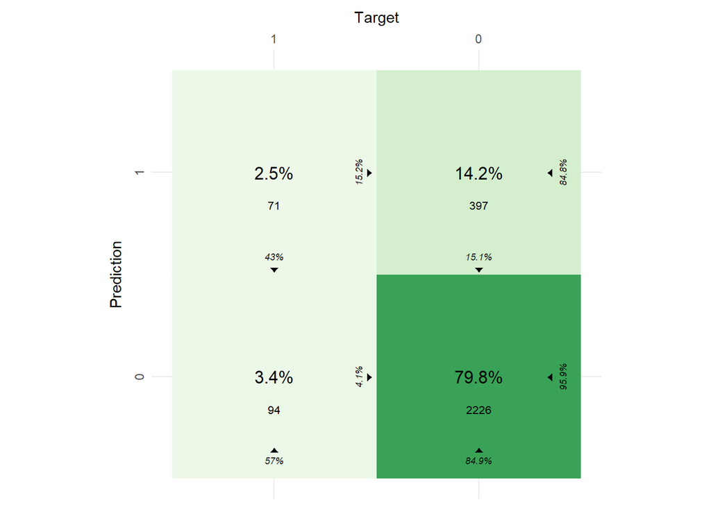

```r
plot_confusion_matrix(model_1_evaluated, palette = "Greens")
```

# Error Analysis

```r
tp_model_1 <- cc_by_results(model_1, "True Positive")
```

```
## # A tibble: 10 x 3
## # Groups:   results [1]
##    results       cc1.x                     count
##    <chr>         <fct>                     <int>
##  1 True Positive COUGH                        20
##  2 True Positive FEVER                        15
##  3 True Positive SOB - SHORTNESS OF BREATH     7
##  4 True Positive SHORTNESS OF BREATH           6
##  5 True Positive COUGH/CONGESTION              6
##  6 True Positive DYSPNEA                       3
##  7 True Positive FEVERS                        3
##  8 True Positive HYPOXIA                       2
##  9 True Positive ILI                           2
## 10 True Positive SHORT OF BREATH               2
```

```r
tn_model_1 <- cc_by_results(model_1, "True Negative")
```

```
## # A tibble: 10 x 3
## # Groups:   results [1]
##    results       cc1.x                       count
##    <chr>         <fct>                       <int>
##  1 True Negative ABD PAIN                      105
##  2 True Negative STOMACH ACHE                   77
##  3 True Negative ABDOMINAL PAIN                 72
##  4 True Negative ABNORMAL LABS                  69
##  5 True Negative S/P FALL                       56
##  6 True Negative AMS - ALTERED MENTAL STATUS    38
##  7 True Negative CHEST PAIN                     38
##  8 True Negative ALTERED MENTAL STATUS          37
##  9 True Negative CHEST PRESSURE                 36
## 10 True Negative BACK PAIN                      33
```

```r
fp_model_1 <- cc_by_results(model_1, "False Positive")
```

```
## # A tibble: 10 x 3
## # Groups:   results [1]
##    results        cc1.x                     count
##    <chr>          <fct>                     <int>
##  1 False Positive FEVER                        83
##  2 False Positive SHORTNESS OF BREATH          60
##  3 False Positive DYSPNEA                      49
##  4 False Positive SOB - SHORTNESS OF BREATH    44
##  5 False Positive COUGH                        39
##  6 False Positive FEVERS                       19
##  7 False Positive SOB                          15
##  8 False Positive DYSPNEA ON EXERTION          14
##  9 False Positive SHORT OF BREATH              14
## 10 False Positive SHORT OF BREATHE             13
```

```r
fn_model_1 <- cc_by_results(model_1, "False Negative")
```

```
## # A tibble: 10 x 3
## # Groups:   results [1]
##    results        cc1.x                 count
##    <chr>          <fct>                 <int>
##  1 False Negative FLU-LIKE SYMPTOMS         5
##  2 False Negative BACK PAIN                 4
##  3 False Negative CP - CHEST PAIN           4
##  4 False Negative STOMACH ACHE              4
##  5 False Negative HYPOXEMIA                 4
##  6 False Negative BODY ACHES                4
##  7 False Negative DIARRHEA                  4
##  8 False Negative ABDOMINAL PAIN            3
##  9 False Negative WEAKNESS                  3
## 10 False Negative ALTERED MENTAL STATUS     3
```

```r
all_results_model_1 <- bind_rows(tp_model_1, tn_model_1, fp_model_1, fn_model_1)

all_results_model_1_wide <- pivot_wider(all_results_model_1, names_from = results, values_from = count, values_fill = 0)

#Beyond top ten
all_results_model_1_wide_tc <-  model_1 %>%
  select(id, cc1.x, results) %>%
  group_by(cc1.x, results) %>%
  summarise(count = n()) %>%
  pivot_wider(names_from = results, values_from = count, values_fill = 0) %>%
  rowwise() %>%
  mutate(total = sum(`True Positive`, `False Negative`, `True Negative`, `False Positive`)) %>%
  mutate(condition_present = sum(`True Positive`, `False Negative`)) %>%
  mutate(cc_pct_positive = round(condition_present/total * 100))
```

# Search Terms Revised

## Potential Search Terms

```r
cc_to_match_a1 <- c("short", "fever", "i l i", " ili ", "\\bili\\b","influe", "covid", "HYPOXIA", "DYSPNEA", "SOB", "cough", "DOE", "Flu-like symptoms", "chest pain", "hypoxemia", "body aches", "diarrhea", "weakness")

cc_to_match_a2 <- c("fever*","shor", "sob", "hypox", "pnea", "doe", "resp", "pulse ox", "i l i", "\\bili\\b","flu", "cough*", "pneumothorax", "FOUND DOWN", "BODY ACHES", "Chest Pain", "diarrhea", "syncope", "lethargy", "transfer", "CP", "weak", "confusion", "CT", "Tomography", "back pain", "HALLUCINATING")
```

## Analysis pipeline

```r
#chosen search term vector
cc_to_match_example <- cc_to_match_a2

#Do not modify anything below here.

predicted_covid_example <- search_assign_by_cc(clean_data, cc_to_match_example, clean_data$cc1)

covid_prediction_counts_example <- covid_prediction_count(predicted_covid_example)
covid_prediction_counts_example
```

```
## # A tibble: 2 x 2
##   covid_guess count
##         <int> <int>
## 1           0  6173
## 2           1  3159
```

```r
model_example <- covid_model_comparison(predicted_covid_example, clean_labeled_data)
model_example_table <- covid_model_comparison_table(model_example)
model_example_table
```

```
## # A tibble: 4 x 3
## # Groups:   covid_status [2]
##   covid_status covid_prediction count
##          <dbl>            <int> <int>
## 1            0                0  1802
## 2            0                1   821
## 3            1                0    44
## 4            1                1   121
```

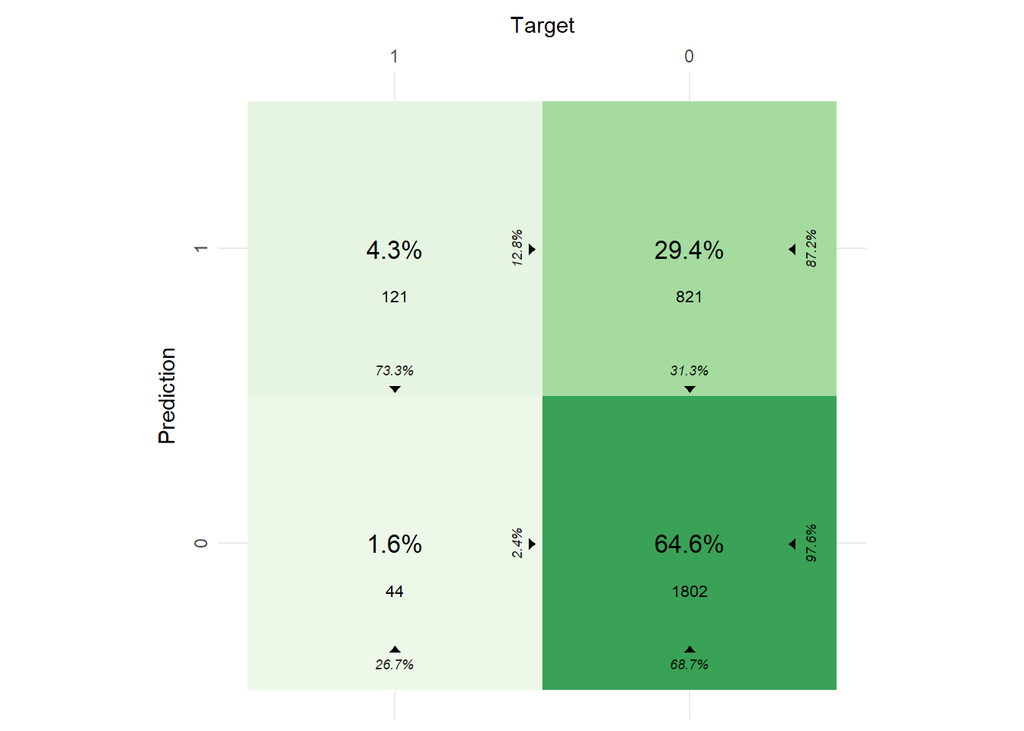

```r
model_example_evaluated <- evaluation_table(model_example)


plot_confusion_matrix(model_example_evaluated, palette = "Greens")
```

```r
tp_model_example <- cc_by_results(model_example, "True Positive", 50)
```

```
## # A tibble: 39 x 3
## # Groups:   results [1]
##    results       cc1.x                     count
##    <chr>         <fct>                     <int>
##  1 True Positive COUGH                        20
##  2 True Positive FEVER                        15
##  3 True Positive SOB - SHORTNESS OF BREATH     7
##  4 True Positive SHORTNESS OF BREATH           6
##  5 True Positive COUGH/CONGESTION              6
##  6 True Positive FLU-LIKE SYMPTOMS             5
##  7 True Positive BACK PAIN                     4
##  8 True Positive CP - CHEST PAIN               4
##  9 True Positive HYPOXEMIA                     4
## 10 True Positive BODY ACHES                    4
## # ... with 29 more rows
```

```r
tn_model_example <- cc_by_results(model_example, "True Negative", 50)
```

```
## # A tibble: 50 x 3
## # Groups:   results [1]
##    results       cc1.x                       count
##    <chr>         <fct>                       <int>
##  1 True Negative ABD PAIN                      105
##  2 True Negative STOMACH ACHE                   77
##  3 True Negative ABDOMINAL PAIN                 72
##  4 True Negative ABNORMAL LABS                  69
##  5 True Negative S/P FALL                       56
##  6 True Negative AMS - ALTERED MENTAL STATUS    38
##  7 True Negative ALTERED MENTAL STATUS          37
##  8 True Negative CHEST PRESSURE                 36
##  9 True Negative DIZZINESS                      32
## 10 True Negative STOMACHACHE                    32
## # ... with 40 more rows
```

```r
fp_model_example <- cc_by_results(model_example, "False Positive", 50)
```

```
## # A tibble: 50 x 3
## # Groups:   results [1]
##    results        cc1.x                     count
##    <chr>          <fct>                     <int>
##  1 False Positive FEVER                        83
##  2 False Positive SHORTNESS OF BREATH          60
##  3 False Positive DYSPNEA                      49
##  4 False Positive SOB - SHORTNESS OF BREATH    44
##  5 False Positive COUGH                        39
##  6 False Positive CHEST PAIN                   38
##  7 False Positive BACK PAIN                    33
##  8 False Positive CP - CHEST PAIN              33
##  9 False Positive DIARRHEA                     33
## 10 False Positive WEAKNESS                     26
## # ... with 40 more rows
```

```r
fn_model_example <- cc_by_results(model_example, "False Negative", 50)
```

```
## # A tibble: 34 x 3
## # Groups:   results [1]
##    results        cc1.x                     count
##    <chr>          <fct>                     <int>
##  1 False Negative STOMACH ACHE                  4
##  2 False Negative ABDOMINAL PAIN                3
##  3 False Negative ALTERED MENTAL STATUS         3
##  4 False Negative ABD PAIN                      2
##  5 False Negative ABNORMAL LABS                 2
##  6 False Negative ABDOMINAL MASS/DISTENTION     2
##  7 False Negative S/P FALL                      1
##  8 False Negative CHEST PRESSURE                1
##  9 False Negative CHEST TIGHTNESS               1
## 10 False Negative SI - SUICIDAL IDEATION        1
## # ... with 24 more rows
```

```r
tp_model_example
```

```
## # A tibble: 39 x 3
## # Groups:   results [1]
##    results       cc1.x                     count
##    <chr>         <fct>                     <int>
##  1 True Positive COUGH                        20
##  2 True Positive FEVER                        15
##  3 True Positive SOB - SHORTNESS OF BREATH     7
##  4 True Positive SHORTNESS OF BREATH           6
##  5 True Positive COUGH/CONGESTION              6
##  6 True Positive FLU-LIKE SYMPTOMS             5
##  7 True Positive BACK PAIN                     4
##  8 True Positive CP - CHEST PAIN               4
##  9 True Positive HYPOXEMIA                     4
## 10 True Positive BODY ACHES                    4
## # ... with 29 more rows
```

```r
tn_model_example
```

```
## # A tibble: 50 x 3
## # Groups:   results [1]
##    results       cc1.x                       count
##    <chr>         <fct>                       <int>
##  1 True Negative ABD PAIN                      105
##  2 True Negative STOMACH ACHE                   77
##  3 True Negative ABDOMINAL PAIN                 72
##  4 True Negative ABNORMAL LABS                  69
##  5 True Negative S/P FALL                       56
##  6 True Negative AMS - ALTERED MENTAL STATUS    38
##  7 True Negative ALTERED MENTAL STATUS          37
##  8 True Negative CHEST PRESSURE                 36
##  9 True Negative DIZZINESS                      32
## 10 True Negative STOMACHACHE                    32
## # ... with 40 more rows
```

```r
fp_model_example
```

```
## # A tibble: 50 x 3
## # Groups:   results [1]
##    results        cc1.x                     count
##    <chr>          <fct>                     <int>
##  1 False Positive FEVER                        83
##  2 False Positive SHORTNESS OF BREATH          60
##  3 False Positive DYSPNEA                      49
##  4 False Positive SOB - SHORTNESS OF BREATH    44
##  5 False Positive COUGH                        39
##  6 False Positive CHEST PAIN                   38
##  7 False Positive BACK PAIN                    33
##  8 False Positive CP - CHEST PAIN              33
##  9 False Positive DIARRHEA                     33
## 10 False Positive WEAKNESS                     26
## # ... with 40 more rows
```

```r
fn_model_example
```

```
## # A tibble: 34 x 3
## # Groups:   results [1]
##    results        cc1.x                     count
##    <chr>          <fct>                     <int>
##  1 False Negative STOMACH ACHE                  4
##  2 False Negative ABDOMINAL PAIN                3
##  3 False Negative ALTERED MENTAL STATUS         3
##  4 False Negative ABD PAIN                      2
##  5 False Negative ABNORMAL LABS                 2
##  6 False Negative ABDOMINAL MASS/DISTENTION     2
##  7 False Negative S/P FALL                      1
##  8 False Negative CHEST PRESSURE                1
##  9 False Negative CHEST TIGHTNESS               1
## 10 False Negative SI - SUICIDAL IDEATION        1
## # ... with 24 more rows
```

```r
all_results <- bind_rows(tp_model_example, tn_model_example, fp_model_example, fn_model_example)

all_results_wide <- pivot_wider(all_results, names_from = results, values_from = count, values_fill = 0)

comparison_new_model_to_model_1 <- bind_rows(model_example_evaluated, model_1_evaluated)


examine_false_negatives <- all_results_wide %>% arrange(desc(`False Negative`))

comparison_new_model_to_model_1
```

```
## # A tibble: 2 x 19
##   `Balanced Accur~ Accuracy    F1 Sensitivity Specificity `Pos Pred Value`
##              <dbl>    <dbl> <dbl>       <dbl>       <dbl>            <dbl>
## 1            0.710    0.690 0.219       0.733       0.687            0.128
## 2            0.639    0.824 0.224       0.430       0.849            0.152
## # ... with 13 more variables: `Neg Pred Value` <dbl>, AUC <dbl>, `Lower
## #   CI` <dbl>, `Upper CI` <dbl>, Kappa <dbl>, MCC <dbl>, `Detection
## #   Rate` <dbl>, `Detection Prevalence` <dbl>, Prevalence <dbl>,
## #   Predictions <list>, ROC <named list>, `Confusion Matrix` <list>,
## #   Process <list>
```

```r
#Beyond top ten
all_results_model_example <-  model_example %>%
  select(id, cc1.x, results) %>%
  group_by(cc1.x, results) %>%
  summarise(count = n()) %>%
  pivot_wider(names_from = results, values_from = count, values_fill = 0) %>%
  rowwise() %>%
  mutate(total = sum(`True Positive`, `False Negative`, `True Negative`, `False Positive`)) %>%
  mutate(condition_present = sum(`True Positive`, `False Negative`)) %>%
  mutate(cc_pct_positive = round(condition_present/total * 100))

model_by_threshold <-  all_results_model_example %>%
  filter(cc_pct_positive > 5)
```

# New Model Output

```r
group_predictions_wk6 <- predicted_covid_example %>% select(1,6)
write_csv(group_predictions_wk6, "./analysis/group3_predictions_wk6.csv")
```

## Metric optimization

We chose to optimize towards sensitivity. This was chosen partially due to clinical/public health considerations and partially as a response to the constraints of the available data and the context of limited information at the specified point in the pandemic. Casting a broader net felt appropriate in the context of a highly contagious and often asymptomatic respiratory illness. False positives are also comparatively unlikely to lead to patient harm in this context –requiring unnecessary isolation – compared to false negatives, which could be much more harmful to other patients and staff. While optimizing for sensitivity, we did also take care to build in precautions against inclusion of similar strings which had no semantic relevance to the symptoms we intended to screen for.

Optimizing for sensitivity has serious draw backs however. Once too many people are flagged as likely COVID positive, the usefulness of test decreases. If the point of the test is help allocate resources such as PPE and isolation rooms, having 50% of your patients flag as likely COVID is perhaps more burdensome than helpful. A high sensitivity test for chief complaint still might useful if another screening step can be applied to that group to further discriminate between those more or less likely to have COVID eg a pulse ox reading or age.